# Soft-bottom depth masks — 100 m

These two masks split the Gulf marine grid into a shelf class and a deep class. They do not change the soft-bottom fraction. That fraction is still the share of each 1 km cell that is not rocky reef or seamount. A later step can multiply the fraction by each mask so soft bottom shallower than 100 m and soft bottom deeper than 100 m are separate habitats.

**Shelf mask.** A 1 km cell is 100 m or shallower when any bathymetry sample inside it has a water depth of 100 m or less. One shallow sample is enough, so cells that straddle the 100 m line go entirely to the shelf class. A marine cell with no in-water sample is also placed here. Those cells are coastal: the OHI cell is marine, but every bathymetry sample in it sits on land or is missing, so the water in the cell is the shallow edge.

**Deep mask.** Every other marine cell. Each of those cells has at least one sample deeper than 100 m and no sample of 100 m or less.

Depth comes from GMRT topography, not from VMS pings. GMRT stores elevation, so water depth is the elevation multiplied by −1. Pixels are about 220 m. They are placed on a 200 m grid nested inside the 1 km cells with nearest neighbor, which keeps the measured depths instead of smoothing them. The 1 km grid is the same EPSG:6372 grid used for the soft-bottom fraction and the vessel-pressure rasters.

```r
library(tidyverse)
library(terra)
library(sf)
library(knitr)
knitr::opts_chunk$set(message = FALSE, warning = FALSE)

gmrt_path <- "/home/shares/ohi/OHI_GOC/_raw_data/GMRT_bathymetry_data/GMRTv4_5_0_20260709topo.tif"
marine_path <- "/home/frazier/ohi_goc_prep/spatial/ohi_regions/ohi_marine_raster_1km.tif"
region_path <- "/home/frazier/ohi_goc_prep/spatial/ohi_regions/goc_ohi_rgns.shp"

out_dir <- "/home/frazier/ohi_goc_prep/_habitats/HAB_soft_bottom/int"
dir.create(out_dir, showWarnings = FALSE, recursive = TRUE)

# 200 m samples inside each 1 km cell. 1000 / 200 = 5, and both raster
# dimensions divide evenly by 5, so the blocks land back on the 1 km cells.
fine_factor <- 5L
depth_break_m <- 100
```

## 1. The 1 km marine grid

Cell values are OHI region ids 1–9. Land and water outside the nine regions are empty. Resolution is 1 km in Mexico ITRF2008 / LCC (EPSG:6372).

```r
region_1km <- rast(marine_path)
marine_1km <- ifel(region_1km >= 1, 1, NA)

region_labels <- st_read(region_path, quiet = TRUE) %>%
  st_drop_geometry() %>%
  filter(location == "marine") %>%
  arrange(rgn_id) %>%
  transmute(
    rgn_num = as.integer(str_remove(rgn_id, "Region_")),
    rgn_id = rgn_id,
    region_label = paste(
      rgn_id,
      str_replace_all(estado, "_", " "),
      str_replace_all(ecorgn, "_", " "),
      sep = " · "
    )
  )

cat(
  "Cells:", ncell(region_1km), "\n",
  "Resolution, m:", paste(res(region_1km), collapse = " × "), "\n",
  "Marine cells:", as.numeric(global(marine_1km, "sum", na.rm = TRUE)[1, 1]), "\n"
)
```

```
## Cells: 1850000
##  Resolution, m: 1000 × 1000
##  Marine cells: 253228
```

## 2. Bathymetry samples inside each 1 km cell

GMRT is cropped to the grid footprint, then projected with nearest neighbor onto the 200 m grid. Water depth is −elevation. A fine cell is shallow when that depth is from 0 through 100 m, and deep when it is greater than 100 m. Land elevations are neither.

```r
template_fine <- disagg(region_1km, fact = fine_factor)

# Geographic box of the 1 km grid, with a small buffer so the edge cells
# still receive a bathymetry sample after the projection.
corners <- cbind(
  x = c(xmin(region_1km), xmax(region_1km), xmin(region_1km), xmax(region_1km)),
  y = c(ymin(region_1km), ymin(region_1km), ymax(region_1km), ymax(region_1km))
)
corners_ll <- project(vect(corners, crs = crs(region_1km)), "EPSG:4326")
ll <- crds(corners_ll)
gmrt_extent <- ext(
  min(ll[, 1]) - 0.3,
  max(ll[, 1]) + 0.3,
  min(ll[, 2]) - 0.3,
  max(ll[, 2]) + 0.3
)

gmrt <- rast(gmrt_path) %>%
  crop(gmrt_extent)

gmrt_fine <- project(gmrt, template_fine, method = "near")
water_depth_m <- -gmrt_fine

shallow_fine <- ifel(is.na(water_depth_m), NA, ifel(water_depth_m >= 0 & water_depth_m <= depth_break_m, 1, 0))
deep_fine <- ifel(is.na(water_depth_m), NA, ifel(water_depth_m > depth_break_m, 1, 0))

# max = 1 when any fine cell in the 1 km block meets the test.
# A block with no in-water samples stays 0. Those coastal cells are assigned
# to the shelf mask in the next section.
shelf_any <- aggregate(shallow_fine, fact = fine_factor, fun = "max", na.rm = TRUE)
```

```
## |---------|---------|---------|---------|=========================================
```

```r
has_deep <- aggregate(deep_fine, fact = fine_factor, fun = "max", na.rm = TRUE)
```

```
## |---------|---------|---------|---------|=========================================
```

```r
shelf_any <- ifel(is.na(shelf_any), 0, shelf_any)
has_deep <- ifel(is.na(has_deep), 0, has_deep)

stopifnot(compareGeom(shelf_any, region_1km, stopOnError = FALSE))
```

## 3. The two masks

Outside the nine marine regions both masks are empty. Inside them, every cell is 1 on exactly one mask. Cells with a measured depth of 100 m or less go to the shelf. Coastal marine cells with no in-water sample go to the shelf as well. The remaining cells go to the deep mask.

```r
# Coastal marine cells whose samples never reach water.
no_water <- ifel(is.na(marine_1km), NA, ifel(shelf_any == 0 & has_deep == 0, 1, 0))

shelf_mask <- ifel(
  is.na(marine_1km),
  NA,
  ifel(shelf_any == 1 | no_water == 1, 1, 0)
)
deep_mask <- ifel(
  is.na(marine_1km),
  NA,
  ifel(shelf_mask == 1, 0, 1)
)
names(shelf_mask) <- "depth_le_100m"
names(deep_mask) <- "depth_gt_100m"

overlap <- ifel(is.na(marine_1km), NA, ifel(shelf_mask == 1 & deep_mask == 1, 1, 0))
unplaced <- ifel(is.na(marine_1km), NA, ifel(shelf_mask == 0 & deep_mask == 0, 1, 0))
# Every deep cell should still have a sample deeper than 100 m.
deep_without_sample <- ifel(is.na(marine_1km), NA, ifel(deep_mask == 1 & has_deep == 0, 1, 0))
stopifnot(as.numeric(global(overlap, "sum", na.rm = TRUE)[1, 1]) == 0)
stopifnot(as.numeric(global(unplaced, "sum", na.rm = TRUE)[1, 1]) == 0)
stopifnot(as.numeric(global(deep_without_sample, "sum", na.rm = TRUE)[1, 1]) == 0)

n_shelf <- as.numeric(global(shelf_mask, "sum", na.rm = TRUE)[1, 1])
n_deep <- as.numeric(global(deep_mask, "sum", na.rm = TRUE)[1, 1])
n_no_water <- as.numeric(global(no_water, "sum", na.rm = TRUE)[1, 1])
n_marine <- as.numeric(global(marine_1km, "sum", na.rm = TRUE)[1, 1])
stopifnot(n_shelf + n_deep == n_marine)
```

Each 1 km cell is 1 km², so the cell count is the area.

```r
area_summary <- tibble(
  class = c(
    "100 m or shallower",
    "    of which, no in-water sample",
    "Deeper than 100 m",
    "All marine cells"
  ),
  cells = c(n_shelf, n_no_water, n_deep, n_marine),
  km2 = cells
)

kable(
  area_summary,
  digits = 0,
  col.names = c("Class", "1 km cells", "Area, km²"),
  caption = "Area of the depth masks. Cells on the 100 m line, and coastal cells with no in-water sample, are in the shallower class."
)
```

Area of the depth masks. Cells on the 100 m line, and coastal cells with no in-water sample, are in the shallower class.

| Class | 1 km cells | Area, km² |
| --- | --- | --- |
| 100 m or shallower | 69168 | 69168 |
| of which, no in-water sample | 859 | 859 |
| Deeper than 100 m | 184060 | 184060 |
| All marine cells | 253228 | 253228 |

```r
class_cells <- c(region_1km, shelf_mask, deep_mask, no_water)
names(class_cells) <- c("rgn_num", "shelf", "deep", "no_water")
class_by_region <- as.data.frame(class_cells, na.rm = TRUE) %>%
  filter(!is.na(rgn_num)) %>%
  group_by(rgn_num) %>%
  summarise(
    shelf_km2 = sum(shelf, na.rm = TRUE),
    no_water_in_shelf_km2 = sum(no_water, na.rm = TRUE),
    deep_km2 = sum(deep, na.rm = TRUE),
    marine_km2 = n(),
    .groups = "drop"
  ) %>%
  left_join(region_labels, by = "rgn_num") %>%
  arrange(rgn_num)

kable(
  class_by_region %>%
    select(region_label, shelf_km2, no_water_in_shelf_km2, deep_km2, marine_km2),
  digits = 0,
  col.names = c("Region", "≤ 100 m, km²", "No sample, counted as ≤ 100 m, km²", "> 100 m, km²", "Marine, km²"),
  caption = "Mask area by OHI marine region. Each 1 km cell counts as 1 km². The no-sample column is already included in the ≤ 100 m column."
)
```

Mask area by OHI marine region. Each 1 km cell counts as 1 km². The no-sample column is already included in the ≤ 100 m column.

| Region | ≤ 100 m, km² | No sample, counted as ≤ 100 m, km² | > 100 m, km² | Marine, km² |
| --- | --- | --- | --- | --- |
| Region_1 · Baja California · Upper Gulf | 2426 | 61 | 0 | 2426 |
| Region_2 · Baja California · Midriff Region | 7737 | 20 | 19514 | 27251 |
| Region_3 · Baja California Sur · Central Gulf | 1536 | 12 | 14954 | 16490 |
| Region_4 · Baja California Sur · Southern Gulf | 3930 | 23 | 101210 | 105140 |
| Region_5 · Sonora · Upper Gulf | 3397 | 24 | 0 | 3397 |
| Region_6 · Sonora · Midriff Region | 14825 | 38 | 9870 | 24695 |
| Region_7 · Sonora · Central Gulf | 6301 | 49 | 14015 | 20316 |
| Region_8 · Sinaloa · Southern Gulf | 18131 | 425 | 10787 | 28918 |
| Region_9 · Nayarit · Southern Gulf | 10885 | 207 | 13710 | 24595 |

```r
write_csv(class_by_region, file.path(out_dir, "depth_mask_km2_by_region.csv"))
```

## 4. Maps

Orange is 100 m or shallower, including coastal cells with no in-water sample. Navy is deeper than 100 m.

```r
class_raster <- ifel(
  is.na(marine_1km),
  NA,
  ifel(shelf_mask == 1, 1, 2)
)

map_df <- as.data.frame(class_raster, xy = TRUE, na.rm = TRUE)
names(map_df)[3] <- "class_id"
map_df <- map_df %>%
  mutate(
    class_label = factor(
      class_id,
      levels = c(1, 2),
      labels = c("100 m or shallower", "Deeper than 100 m")
    )
  )
```

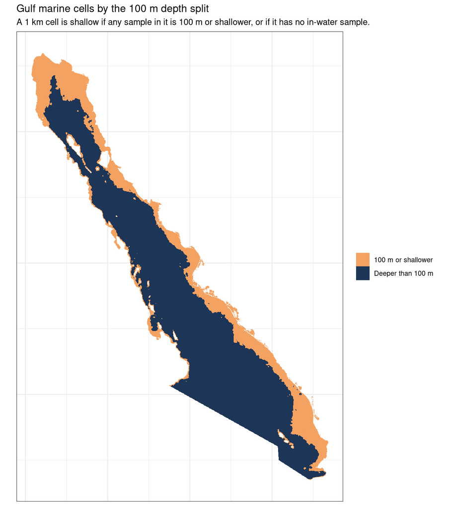

```r
mask_plot <- ggplot(map_df, aes(x, y, fill = class_label)) +
  geom_raster() +
  scale_fill_manual(
    values = c(
      "100 m or shallower" = "#f4a261",
      "Deeper than 100 m" = "#1d3557"
    ),
    name = NULL
  ) +
  coord_equal() +
  labs(
    title = "Gulf marine cells by the 100 m depth split",
    subtitle = "A 1 km cell is shallow if any sample in it is 100 m or shallower, or if it has no in-water sample.",
    x = NULL,
    y = NULL
  ) +
  theme_bw() +
  theme(axis.text = element_blank(), axis.ticks = element_blank())

print(mask_plot)
```

```r
ggsave(
  file.path(out_dir, "depth_masks_100m_1km.png"),
  mask_plot,
  width = 8,
  height = 9,
  dpi = 150,
  bg = "white"
)
```

## 5. Saved rasters

Values are 1 inside the class, 0 in the other marine cells, and empty outside the nine marine regions. Every marine cell is 1 on one raster. Coastal cells with no in-water sample are 1 on the shelf raster.

```r
shelf_path <- file.path(out_dir, "mask_depth_le_100m_1km.tif")
deep_path <- file.path(out_dir, "mask_depth_gt_100m_1km.tif")

writeRaster(shelf_mask, shelf_path, overwrite = TRUE, datatype = "INT1U", NAflag = 255)
writeRaster(deep_mask, deep_path, overwrite = TRUE, datatype = "INT1U", NAflag = 255)

cat("Shelf mask:", shelf_path, "\n")
```

```
## Shelf mask: /home/frazier/ohi_goc_prep/_habitats/HAB_soft_bottom/int/mask_depth_le_100m_1km.tif
```

```r
cat("Deep mask:", deep_path, "\n")
```

```
## Deep mask: /home/frazier/ohi_goc_prep/_habitats/HAB_soft_bottom/int/mask_depth_gt_100m_1km.tif
```

```r
cat("Shelf file, KB:", round(file.size(shelf_path) / 1024), "\n")
```

```
## Shelf file, KB: 58
```

```r
cat("Deep file, KB:", round(file.size(deep_path) / 1024), "\n")
```

```
## Deep file, KB: 58
```

The shelf raster is /home/frazier/ohi_goc_prep/_habitats/HAB_soft_bottom/int/mask_depth_le_100m_1km.tif. The deep raster is /home/frazier/ohi_goc_prep/_habitats/HAB_soft_bottom/int/mask_depth_gt_100m_1km.tif.